# walkthrough

## **Using the RGSM Recruitment Tool to Compare Restoration Sites**

### **Overview**

This walkthrough will guide you through using the Rio Grande Silvery Minnow (RGSM) Recruitment tool to estimate RGSM recruitment increases related to one or more potential restoration sites and exporting results that can be used to compare recruitment benefits across sites.

The tool is accessible here: https://wrises.shinyapps.io/rgsm-recruit/

### **Step 1: Set up your flow years**

To assess potential restoration benefits, you will need to determine which years to use to examine how recruitment of RGSM would have changed with a given restoration project.

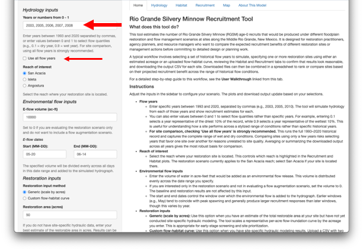

In the sidebar under **Hydrology inputs**, you have two options:

- **Check "Use all flow years"** to run the full historical record (1993–2020). This is the recommended approach for comparing sites, as it captures a wide range of wet and dry conditions and gives you the most complete picture of how a site performs across different hydrologic conditions.
- **Enter specific years** separated by commas (e.g. 2003, 2005, 2010) if you are interested in particular flow conditions — for example, a recent drought period or a set of years representative of projected future hydrology.
- **Alternatively, enter values between 0 and 1** to select flow quantiles rather than specific years. For example, entering 0.1 selects a year representative of the driest 10% of the record, while 0.9 selects a year representative of the wettest 10%. This is useful for understanding how a site performs across a stylized range of conditions rather than specific historical years."

### **Step 2: Select your reach**

Under **Reach of interest**, select the reach of the Middle Rio Grande where your restoration site is located.

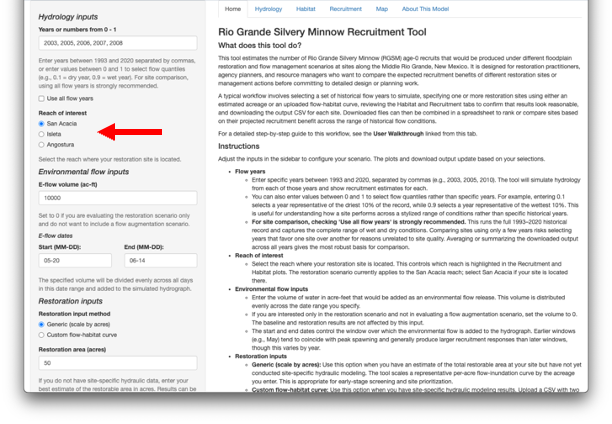

### **Step 3: Leave environmental flow inputs at defaults (or adjust if needed)**

Users can compare the effects of restoration on recruitment to the effects of environmental flows, since it’s a common measure used to increase RGSM recruitment and can help provide context on restoration effectiveness. However, this is not necessary. For a site comparison focused purely on restoration benefits, you can leave the **E-flow volume** at its default or set it to 0. The restoration and baseline scenarios do not depend on this input — it only affects the flow augmentation scenario shown in the plots.

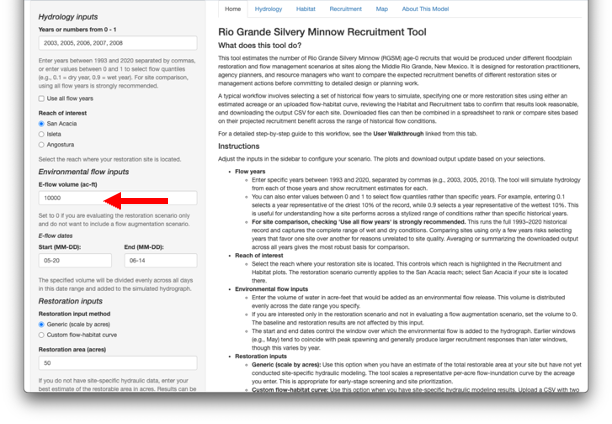

### **Step 4: Enter Restoration site hydraulic details**

Under **Restoration inputs**, choose how you want to define the flow-habitat relationship for your site:

**Option A — Generic (scale by acres):** If you know the approximate size of your restoration area in acres but do not have site-specific hydraulic data, enter the acreage in the **Restoration area** box. The tool will scale a representative per-acre flow-habitat curve by that number.

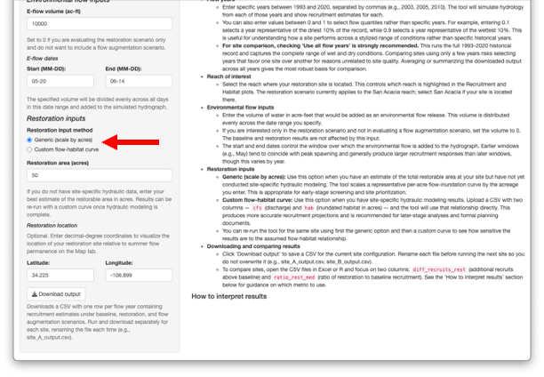

**Option B — Custom flow-habitat curve:** If you have site-specific hydraulic modeling output, select **Custom flow-habitat curve** and upload a CSV with two columns:

- cfs — discharge values
- hab — inundated habitat in acres at your site for each discharge

This is the preferred option if you have it, as it will give a more accurate representation of your specific site's inundation dynamics.

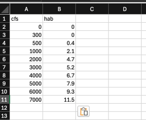

### **Step 5: Explore the plots (optional but recommended)**

Before exporting, it is worth reviewing the **Habitat** and **Recruitment** tabs to check that results look reasonable:

- The **Habitat tab** shows how much inundated habitat your site adds above the baseline across different flow years. Check that the restoration scenario (salmon line) is elevated above the baseline (black line) at flows where you would expect inundation.
- The **Recruitment tab** shows estimated age-0 recruitment under the baseline and restoration scenarios across all flow years. The upper panel shows total recruits on a log scale; the lower panel shows recruits above baseline. Wetter years (higher x-axis values) generally show larger absolute benefits.

### **Step 6: Download the output**

Click **Download output** in the sidebar. This saves a CSV file containing one row per flow year for your selected reach, with columns including:

- flow_years — the year each row corresponds to
- recruits_baseline — estimated baseline recruitment
- recruits_rest — estimated recruitment under your restoration scenario (i.e., baseline plus additional restoration effects)
- diff_recruits_rest — additional recruits above baseline
- ratio_rest_med — ratio of restoration recruitment to baseline recruitment (e.g. a value of 1.25 means 25% more recruits than baseline)

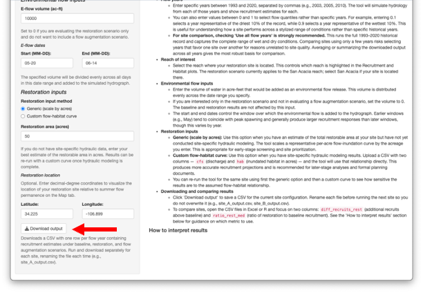

### **Step 7: Repeat for each site**

Go back to Step 4 and enter the next site — either a different acreage or a new custom CSV — then download the output again. Rename each downloaded file to reflect the site (e.g. rgsm_output_siteA.csv, rgsm_output_siteB.csv) so they are easy to tell apart.

### **Step 8: Compare sites in a spreadsheet**

Once you have a CSV for each site, open them in Excel or R and combine them. The two most useful columns for comparison are:

- **diff_recruits_rest** — the raw number of additional recruits. Summing or averaging this across years tells you the total or average absolute benefit of each site. This metric favors sites that perform well in wet years, when baseline recruitment is already high and absolute gains are larger.
- **ratio_rest_med** — the ratio of restoration to baseline recruitment. Averaging this across years tells you how consistently a site amplifies recruitment relative to conditions. This metric is more informative for sites that provide meaningful benefits even in dry years, when absolute gains are small but proportional gains may still be large.

Depending on your management goals, you may weight one metric more than the other, or look at both. A site with a high average ratio but low average difference may be highly efficient per acre but limited in absolute fish production. A site with a high average difference may deliver large absolute gains but only in wet years.